# STAT443 Group Project

## Automatically-Fitted Models

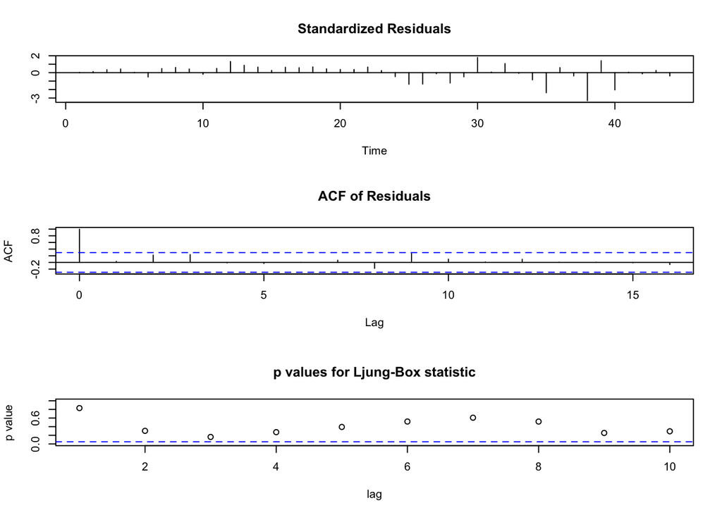

```r
JanToMarAuto = auto.arima(JanToMar$Adj.Close)
tsdiag(JanToMarAuto)
```

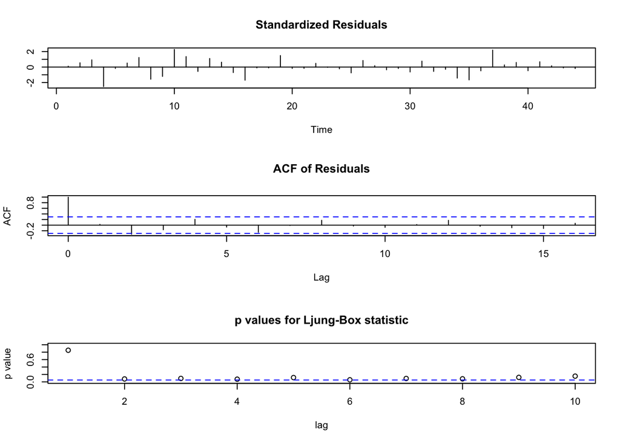

```r
#ARIMA(1,1,0)

JanToMar2019Auto = auto.arima(JanToMar2019$Adj.Close)
tsdiag(JanToMar2019Auto)
```

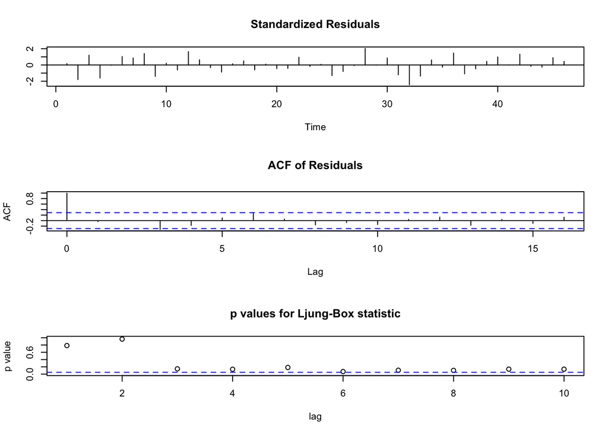

```r
#ARIMA(0,1,0)

OctToDecAuto = auto.arima(OctToDec$Adj.Close)
tsdiag(OctToDecAuto)
```

```r
#ARIMA(0,1,0)
```

Global pandemics are not common variables to include within models, and so, as we are presented with the opportunity to see how an actual pandemic can affect model fitting, we decided to use the auto.arima() function from the package “forecast”. The best ARIMA models were automatically fit by the function based on AIC. First looking at both the 2019 series, auto.arima() returns an ARIMA(0,1,0), while an ARIMA(1,1,0) is returned for the January to March 2020 series.

As expected, the time series affected by the pandemic deviates from the other two. Intuitively, one would think a model based on a stock market index should exhibit AR(P) coefficients, where P > 0. Thus, by removing stationary effects such as a trend on what we suspect is an AR(1) model, sequential observations in a differenced series should only be dictated by white noise. This is confirmed by the ARIMA(0,1,0) models returned by auto.arima() for both the 2019 series.

```
Since fitted models do not capture reality perfectly and exhaustively, we can see the realization of this limitation in the auto-fit model of the January to March 2020 time series. An ARIMA(1,1,0) model is returned, suggesting that sequential observations are based off the previous one after first differencing. Of course, it is out of our reach to validate pandemic affected models, but nevertheless it is interesting to see how it affects current methods of modelling.
```

## Forecasting Model

To see how much the real data for January to March 2020 diverged, we can compare it to the forecasted values of a Holt-Winters model trained on the data for October to December 2019, where the NASDAQ index still seemed to be behaving “normally”. While there is a grain of salt to be taken here with such a forecasted model since we’re essentially forecasting as many data points as there are in the training set, We think it’ll still be an interesting comparison to make.

```r
hw <- HoltWinters(as.ts(OctToDec$Adj.Close,frequency=7), alpha = NULL, beta = NULL,
gamma = FALSE, seasonal = c("additive", "multiplicative"), l.start = NULL, b.start = NULL, s.start = NULL, optim.start = c(alpha = 0.3, beta = 0.1, gamma =0.1), optim.control = list())
hw
```

```
## Holt-Winters exponential smoothing with trend and without seasonal component.
##
## Call:
## HoltWinters(x = as.ts(OctToDec$Adj.Close, frequency = 7), alpha = NULL,     beta = NULL, gamma = FALSE, seasonal = c("additive", "multiplicative"),     l.start = NULL, b.start = NULL, s.start = NULL, optim.start = c(alpha = 0.3,         beta = 0.1, gamma = 0.1), optim.control = list())
##
## Smoothing parameters:
##  alpha: 1
##  beta : 0.2407177
##  gamma: FALSE
##
## Coefficients:
##         [,1]
## a 8924.95996
## b   33.53791
```

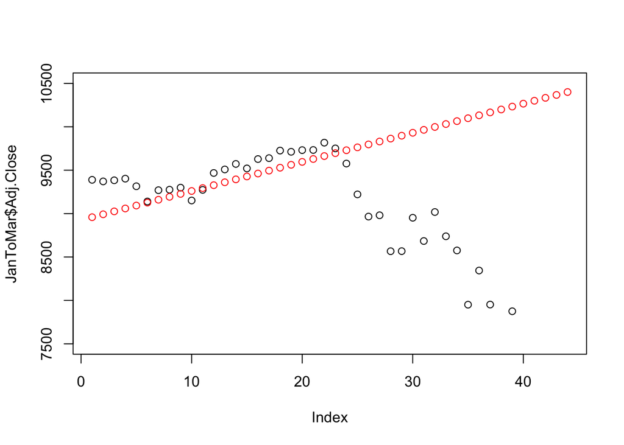

```r
JanToMar.predict <- predict(hw, n.ahead = 44)
plot(JanToMar$Adj.Close, ylim=c(7500,10500))
points(1:44, JanToMar.predict,col="2")
```

### Analysis of Forecast As we can see, with the dearth of data the Holt-Winters method resulted in a prediction that appears almost linear. However, the predictions for a look-ahead of 44 actually appears to fit the data quite well for the data points leading up to before news and concerns of coronavirus really spread. The data only really diverges from this model starting in the time point corresponding to early Feburary where the markets started reacting.

It’s certainly hard to say for sure with how our forecast model was fitted, and how the models don’t account for anything other potential shift in trends, the NASDAQ index maybe have continued experiencing a positive trend throughout Febuary and into March.

## Conclusion

In conclusion, our models show that Covid-19 affected the NASDAQ adjusted closing price in a few facets. It greatly increased the day to day volatility of the daily change in the price as evidenced by our analysis of the time series for the first differences. It has also certianly shifted the course of the trend to be a steep negative trend as opposed to the gentle positive trend that the data from the preceeding 3 months would indicate.

All in all, our expectations that the growing concerns of the Coronavirus would greatly impact the adjusted closing price of NASDAQ were met fully. Through our analysis, we have come to see how we should not blindly follow models and believe they can predict major events such as this one.